# Estudo de Comparação de Métodos de Captação de Material Particulado PM2.5

Rafael Marques Ribeiro

2025-10-11

## **Introdução**

Este estudo realiza uma análise comparativa da qualidade do ar no estado da Paraíba, focando nas concentrações de material particulado fino (PM2.5) durante os anos de 2022 e 2023. A investigação utiliza dados provenientes de duas fontes distintas: o sistema CAMS (Copernicus Atmosphere Monitoring Service), que fornece observações diárias, e a base Donkelar, que disponibiliza dados já agregados em médias mensais. A análise emprega boxplots para visualizar a distribuição mensal dos dados, permitindo identificar padrões sazonais, variações e a presença de valores atípicos. Complementarmente, as análises de frequência por categorias de impacto são utilizadas para contextualizar esses outliers, demonstrando que mesmo valores extremos podem permanecer dentro de faixas consideradas satisfatórias quando a maior parte dos dados se concentra em níveis baixos de poluição.

## **Metodologia**

A metodologia adotada compreende quatro etapas principais: (1) comparação entre métodos de mensuração através de boxplots mensais para 2022 e 2023; (2) análise de frequência por categorias de impacto (0-5 µg/m³ - Ideal, 5-10 - Baixo, 10-15 - Moderado, 15-20 - Alto, >20 - Muito Alto); (3) mapeamento espacial das médias anuais com escala unificada (0-20 µg/m³); e (4) análise das diferenças interanuais (2023-2022) com representação em escala divergente (-5 a +5 µg/m³). Todas as análises foram realizadas de forma comparativa entre os métodos CAMS e Donkelar, considerando a natureza distinta de suas bases de dados.

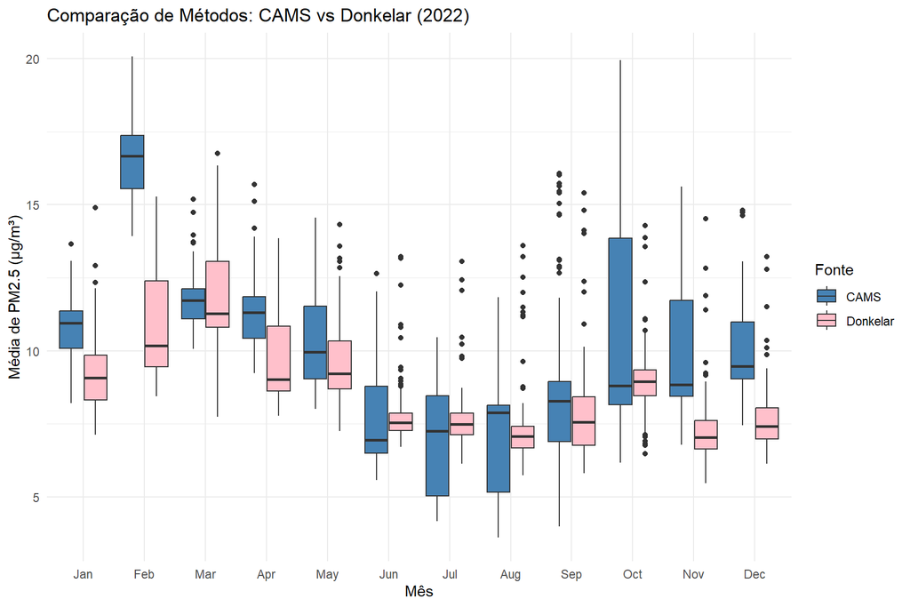

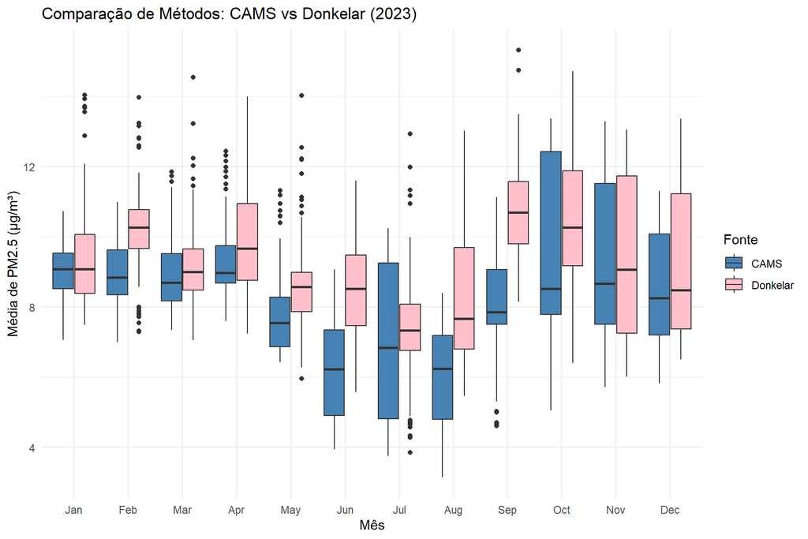